# Effect of CFP on CSR

# Statistical analysis

## Initial setup

- Using renv to lock in dependencies
- Using git for version control
- Created an r project

## Data prep

- Load and examine data

```
[1] "data.table" "data.frame"
Classes ‘data.table’ and 'data.frame':  1195 obs. of  25 variables:
 $ Sector            : Factor w/ 9 levels "Basic Materials",..: 2 2 2 2 2 2 2 2 2 2 ...
 $ Country           : Factor w/ 6 levels "Botswana","Ghana",..: 5 5 5 5 5 6 6 6 6 6 ...
 $ n_com_educ        : num  0 0 2 0 0 0 0 0 0 0 ...
 $ n_com_hlth        : num  0 0 0 0 0 0 0 0 0 0 ...
 $ n_com_art         : num  0 0 1 0 0 1 0 0 0 2 ...
 $ n_com_econ        : num  1 0 1 0 0 1 0 1 1 1 ...
 $ n_com_agric       : num  0 0 1 0 0 0 1 1 2 2 ...
 $ n_com_activism    : num  0 0 1 0 0 0 1 0 2 4 ...
 $ n_hr_safety       : num  0 0 2 0 0 0 2 0 1 1 ...
 $ n_hr_diversity    : num  0 0 1 0 0 0 0 0 0 0 ...
 $ n_hr_training     : num  0 0 2 0 0 0 1 0 0 0 ...
 $ n_hr_benefits     : num  0 0 5 0 2 2 1 4 4 4 ...
 $ n_hr_monitoring   : num  0 0 1 0 0 0 0 1 1 1 ...
 $ n_hr_satisfaction : num  0 0 1 0 0 1 0 0 0 0 ...
 $ n_prod_info       : num  0 0 0 0 0 0 1 0 0 0 ...
 $ n_prod_quality    : num  0 0 0 0 0 0 1 1 1 1 ...
 $ n_ene_conservation: num  0 0 0 0 0 2 0 0 1 1 ...
 $ n_ene_policy      : num  0 0 0 0 0 0 0 0 1 0 ...
 $ n_emi_policy      : num  0 0 0 0 0 1 3 0 3 1 ...
 $ n_emi_practice    : num  0 0 0 0 0 0 0 0 0 0 ...
 $ n_env_pollution   : num  0 0 0 0 0 0 1 0 1 1 ...
 $ n_env_conservation: num  0 0 0 0 0 0 1 0 0 0 ...
 $ n_env_policy      : num  0 0 0 0 0 0 0 0 0 0 ...
 $ n_env_water       : num  0 0 0 0 0 1 2 1 1 1 ...
 $ n_oth_other       : num  0 0 3 0 0 0 0 0 2 3 ...
 - attr(*, ".internal.selfref")=<externalptr>
```

| Sector | Country | n_com_educ | n_com_hlth | n_com_art | n_com_econ | n_com_agric | n_com_activism | n_hr_safety | n_hr_diversity | n_hr_training | n_hr_benefits | n_hr_monitoring | n_hr_satisfaction | n_prod_info | n_prod_quality | n_ene_conservation | n_ene_policy | n_emi_policy | n_emi_practice | n_env_pollution | n_env_conservation | n_env_policy | n_env_water | n_oth_other |
| --- | --- | --- | --- | --- | --- | --- | --- | --- | --- | --- | --- | --- | --- | --- | --- | --- | --- | --- | --- | --- | --- | --- | --- | --- |
| Consumer Goods | Nigeria | 0 | 0 | 0 | 1 | 0 | 0 | 0 | 0 | 0 | 0 | 0 | 0 | 0 | 0 | 0 | 0 | 0 | 0 | 0 | 0 | 0 | 0 | 0 |
| Consumer Goods | Nigeria | 0 | 0 | 0 | 0 | 0 | 0 | 0 | 0 | 0 | 0 | 0 | 0 | 0 | 0 | 0 | 0 | 0 | 0 | 0 | 0 | 0 | 0 | 0 |
| Consumer Goods | Nigeria | 2 | 0 | 1 | 1 | 1 | 1 | 2 | 1 | 2 | 5 | 1 | 1 | 0 | 0 | 0 | 0 | 0 | 0 | 0 | 0 | 0 | 0 | 3 |
| Consumer Goods | Nigeria | 0 | 0 | 0 | 0 | 0 | 0 | 0 | 0 | 0 | 0 | 0 | 0 | 0 | 0 | 0 | 0 | 0 | 0 | 0 | 0 | 0 | 0 | 0 |
| Consumer Goods | Nigeria | 0 | 0 | 0 | 0 | 0 | 0 | 0 | 0 | 0 | 2 | 0 | 0 | 0 | 0 | 0 | 0 | 0 | 0 | 0 | 0 | 0 | 0 | 0 |
| Consumer Goods | South Africa | 0 | 0 | 1 | 1 | 0 | 0 | 0 | 0 | 0 | 2 | 0 | 1 | 0 | 0 | 2 | 0 | 1 | 0 | 0 | 0 | 0 | 1 | 0 |

```
$Sector
   Basic Materials     Consumer Goods  Consumer Services         Healthcare        Industrials        Oil and Gas         Technology Telecommunications          Utilities
               236                250                215                 35                260                 85                 75                 20                 19

$Country
    Botswana        Ghana        Kenya    Mauritius      Nigeria South Africa
          45           35          130           65          225          695

$n_com_educ
   Min. 1st Qu.  Median    Mean 3rd Qu.    Max.
  0.000   0.000   1.000   1.263   2.000   7.000

$n_com_hlth
   Min. 1st Qu.  Median    Mean 3rd Qu.    Max.
0.00000 0.00000 0.00000 0.05021 0.00000 2.00000

$n_com_art
   Min. 1st Qu.  Median    Mean 3rd Qu.    Max.
 0.0000  0.0000  0.0000  0.4762  1.0000  4.0000

$n_com_econ
   Min. 1st Qu.  Median    Mean 3rd Qu.    Max.
  0.000   1.000   1.000   1.328   2.000   6.000

$n_com_agric
   Min. 1st Qu.  Median    Mean 3rd Qu.    Max.
 0.0000  0.0000  1.0000  0.7992  1.0000  5.0000

$n_com_activism
   Min. 1st Qu.  Median    Mean 3rd Qu.    Max.
  0.000   0.000   1.000   1.331   2.000   7.000

$n_hr_safety
   Min. 1st Qu.  Median    Mean 3rd Qu.    Max.
  0.000   0.000   1.000   1.669   3.000   8.000

$n_hr_diversity
   Min. 1st Qu.  Median    Mean 3rd Qu.    Max.
 0.0000  0.0000  0.0000  0.1431  0.0000  2.0000

```

[output cut: 44 more lines]

```
$n_env_conservation
   Min. 1st Qu.  Median    Mean 3rd Qu.    Max.
  0.000   0.000   0.000   0.913   2.000   8.000

$n_env_policy
   Min. 1st Qu.  Median    Mean 3rd Qu.    Max.
 0.0000  0.0000  0.0000  0.5556  1.0000  4.0000

$n_env_water
   Min. 1st Qu.  Median    Mean 3rd Qu.    Max.
 0.0000  0.0000  0.0000  0.4971  1.0000  4.0000

$n_oth_other
   Min. 1st Qu.  Median    Mean 3rd Qu.    Max.
  0.000   0.000   1.000   1.429   3.000   7.000
```

### Descriptive table (table 1)

```r
desc_stats <- list('Mean' = mean, 'Median' = median, 'SD' = sd, 'Min' = min, 'Max' = max)
var_labels <- c('Education', 'Public health', 'Arts and culture', 'Economy', 'Agriculture', 'Social activism',
                'Workplace safety', 'Workforce diversity', 'Employee training', 'Employee benefits', 'Workplace monitoring', 'Employee satisfaction',
                'Product information', 'Product quality',
                'Energy conservation', 'Energy policy',
                'Emissions policy', 'Emissions-reduction practices',
                'Pollution-reduction', 'Conservation activities', 'Environmental Policy', 'Water policy',
                'Other CSR activities')

pca_vars <- names(pca_data)[grepl('^n_', names(pca_data))]
names(var_labels) <- pca_vars

pca_data %>%
  select(all_of(pca_vars)) %>%
  desctable(stats = desc_stats, labels = var_labels) %>%
  as.data.frame %>%
  hux %>%
  set_header_rows(1, TRUE) %>%
  style_headers(bold = TRUE, text_color = "grey40") %>%
  set_caption('Summary of CSR domain variables') %>%
  theme_article()
```

```
                                                                       Summary of CSR domain variables
                                                   ────────────────────────────────────────────────────────────────────────
                                                                                    Mean   Median      SD     Min     Max
                                                   ────────────────────────────────────────────────────────────────────────
                                                     Education                    1.26          1   1.41        0       7
                                                     Public health                0.0502        0   0.233       0       2
                                                     Arts and culture             0.476         0   0.639       0       4
                                                     Economy                      1.33          1   1.02        0       6
                                                     Agriculture                  0.799         1   0.879       0       5
                                                     Social activism              1.33          1   1.38        0       7
                                                     Workplace safety             1.67          1   1.8         0       8
                                                     Workforce diversity          0.143         0   0.367       0       2
                                                     Employee training            1.31          2   1.21        0       4
                                                     Employee benefits            3.39          3   2.25        0      16
                                                     Workplace monitoring         0.856         0   1.08        0       6
                                                     Employee satisfaction        0.946         1   1.01        0       6
                                                     Product information          0.348         0   0.52        0       2
                                                     Product quality              0.982         1   1.19        0       6
                                                     Energy conservation          0.57          0   0.891       0       5
                                                     Energy policy                0.571         0   0.707       0       4
                                                     Emissions policy             0.602         0   1.22        0       7
                                                     Emissions-reduction          0.0192        0   0.143       0       2
                                                     practices
                                                     Pollution-reduction          0.28          0   0.608       0       4
                                                     Conservation activities      0.913         0   1.24        0       8
                                                     Environmental Policy         0.556         0   0.818       0       4
                                                     Water policy                 0.497         0   0.768       0       4
                                                     Other CSR activities         1.43          1   1.43        0       7
                                                   ────────────────────────────────────────────────────────────────────────

Column names:  , Mean, Median, SD, Min, Max
```

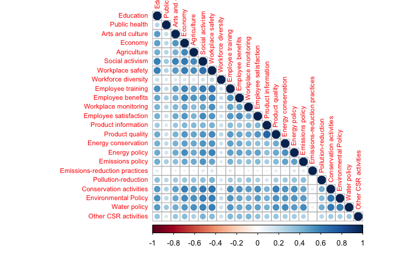

```r
pca_data %>%
  select(all_of(pca_vars)) %>%
  setnames(pca_vars, var_labels) %>%
  cor %>%
  corrplot(type = 'lower', tl.cex = .7)
```

### PCA analysis

```r
pca_data %>%
  select(all_of(pca_vars)) %>%
  prcomp(center = T, rank. = 10) -> pca_res
```

```r
pca_res %>%
  tidy(matrix = 'd') %>%
  slice(1:10) %>%
  mutate(percent = percent*100, cumulative = cumulative*100) %>%
  as_hux -> tab

tab %>%
  set_header_rows(1, TRUE) %>%
  set_contents(1, 1:4, c("Prin. Comp", "Std. Dev.", "% explained", "Cummulative %")) %>%
  style_headers(bold = TRUE, text_color = "grey40") %>%
  set_caption('Percentage of variance explained by first 10 principal components') %>%
  theme_article()
```

```
                                                       Percentage of variance explained by first 10 principal components
                                                           ────────────────────────────────────────────────────────
                                                             Prin. Comp   Std. Dev.   % explained   Cummulative %
                                                           ────────────────────────────────────────────────────────
                                                                      1       3.87          53.4             53.4
                                                                      2       1.52           8.31            61.8
                                                                      3       1.26           5.71            67.5
                                                                      4       1.06           3.98            71.4
                                                                      5       1.04           3.87            75.3
                                                                      6       0.954          3.25            78.6
                                                                      7       0.866          2.68            81.2
                                                                      8       0.816          2.38            83.6
                                                                      9       0.801          2.29            85.9
                                                                     10       0.762          2.07            88
                                                           ────────────────────────────────────────────────────────

Column names: PC, std.dev, percent, cumulative
```

```r
pca_res %>%
  tidy(matrix = 'v') %>%
  spread(key = PC, value = value) %>%
  select(-column) %>%
  mutate(`CSR domain` = var_labels) %>%
  relocate(`CSR domain`) %>%
  hux -> tab

tab %>% insert_row('', 'Principal component', '', '', '', '', '', '', '', '', '', after = 0) %>%
  merge_cells(1, 2:11) %>%
  set_col_width(c(1, rep(.5, 10))) %>%
  set_header_rows(1:2, TRUE) %>%
  style_headers(bold = TRUE, text_color = "grey40") %>%
  set_caption('Loadings of CSR domains on first 10 principal components') %>%
  theme_article()
```

```
                                                           Loadings of CSR domains on first 10 principal components
                  ──────────────────────────────────────────────────────────────────────────────────────────────────────────────────────────────────────────
                                              Principal component
                    CSR domain                      1          2          3           4           5          6          7          8          9         10
                  ──────────────────────────────────────────────────────────────────────────────────────────────────────────────────────────────────────────
                    Education                 0.29      -0.159      0.00159    0.106       0.223      -0.0198    -0.595      0.0918    -0.36       0.237
                    Public health             0.153     -0.0237    -0.0911     0.113       0.0122      0.05      -0.103     -0.0391     0.0923    -0.284
                    Arts and culture          0.104     -0.0494     0.0111     0.0052      0.0481     -0.0532    -0.099      0.0704    -0.0679    -0.00185
                    Economy                   0.202     -0.016     -0.0241     0.107      -0.0391      0.00548   -0.158      0.118     -0.0203    -0.222
                    Agriculture               0.258     -0.217     -0.00598   -0.404       0.611      -0.508      0.254     -0.042      0.0315    -0.0504
                    Social activism           0.02      -0.00163   -0.0102     0.0166      0.0236      0.0144     0.0146     0.00933   -0.023      0.0024
                    Workplace safety          0.189     -0.256     -0.104      0.503       0.388       0.434      0.287     -0.123      0.23       0.245
                    Workforce diversity       0.00378   -0.0109    -0.00397   -0.00642    -0.000515    0.00257   -0.00314   -0.00329    0.00563    0.0146
                    Employee training         0.147     -0.0946    -0.0579     0.132       0.0182      0.109      0.0536     0.0442     0.0638    -0.403
                    Employee benefits         0.124     -0.0602    -0.0443     0.0609     -0.0205      0.0826     0.018      0.0445    -0.0403    -0.0151
                    Workplace monitoring      0.249     -0.15      -0.152      0.171      -0.238      -0.144      0.0315     0.0116    -0.44      -0.375
                    Employee satisfaction     0.152     -0.125     -0.0819     0.0873     -0.00353    -0.0382    -0.00307   -0.0404    -0.0598    -0.0983
                    Product information       0.0727    -0.0703    -0.00985    0.0158      0.0293      0.0594     0.127     -0.0107    -0.131     -0.0794
                    Product quality           0.141     -0.12      -0.0542     0.123      -0.00645     0.0274     0.0959     0.00465   -0.024     -0.094
                    Energy conservation       0.473      0.841     -0.139      0.0161      0.114       0.0321     0.0785    -0.0927     0.0289    -0.0137
                    Energy policy             0.0234    -0.0018     0.0244    -0.0177     -0.014      -0.0176     0.038     -0.024      0.0201     0.0282
                    Emissions policy          0.182     -0.0171     0.132     -0.000685   -0.199      -0.00513    0.494      0.719     -0.145      0.169
                    Emissions-reduction       0.396     -0.226     -0.097     -0.601      -0.317       0.441      0.0605    -0.281     -0.0399     0.166
                    practices
                    Pollution-reduction       0.18       0.0306    -0.00635    0.153      -0.109      -0.198     -0.139      0.0656    -0.0853     0.571
                    Conservation activities   0.237     -0.0916     0.0467    -0.129      -0.0557      0.0178    -0.364      0.425      0.663     -0.112
                    Environmental Policy      0.194      0.0234     0.945      0.0709      0.0177      0.0799     0.00376   -0.18      -0.0521    -0.106
                    Water policy              0.0698    -0.0509     0.0142     0.0933     -0.16       -0.148      0.0266    -0.0809     0.123      0.0602
                    Other CSR activities      0.212     -0.131     -0.0154     0.242      -0.412      -0.489      0.129     -0.346      0.305      0.115
                  ──────────────────────────────────────────────────────────────────────────────────────────────────────────────────────────────────────────

Column names: CSR domain, 1, 2, 3, 4, 5, 6, 7, 8, 9, 10
```

### PCA results (Figures)

```r
# Component loadings

rownames(pca_res$rotation) <- var_labels
pca_res$rotation
```

```
                                      PC1          PC2          PC3          PC4           PC5          PC6          PC7          PC8         PC9         PC10
Education                     0.257799892 -0.216896074 -0.005975050 -0.404119224  0.6108075736 -0.508093173  0.253917894 -0.041966554  0.03149530 -0.050424651
Public health                 0.019959518 -0.001627572 -0.010191282  0.016618880  0.0236391318  0.014435544  0.014563241  0.009334793 -0.02295674  0.002395814
Arts and culture              0.103522867 -0.049420763  0.011061143  0.005196357  0.0480925316 -0.053249594 -0.099001544  0.070434501 -0.06787234 -0.001852379
Economy                       0.202487359 -0.015964696 -0.024088941  0.107240987 -0.0390652557  0.005480384 -0.158164543  0.117815984 -0.02032494 -0.222062609
Agriculture                   0.153448952 -0.023663445 -0.091079302  0.113336364  0.0121890934  0.049976949 -0.102685585 -0.039078731  0.09234275 -0.283683165
Social activism               0.289998580 -0.159395581  0.001592374  0.106046947  0.2225520235 -0.019793948 -0.594532777  0.091829677 -0.36007664  0.236759931
Workplace safety              0.396423100 -0.226244287 -0.097038752 -0.601381147 -0.3174189015  0.440815950  0.060451235 -0.281320486 -0.03991180  0.166192255
Workforce diversity           0.023415841 -0.001802605  0.024434545 -0.017672127 -0.0140443074 -0.017637818  0.038014173 -0.023989017  0.02007944  0.028239258
Employee training             0.237210108 -0.091568807  0.046686204 -0.128749375 -0.0556672018  0.017795333 -0.364107594  0.424649043  0.66332066 -0.112249667
Employee benefits             0.473271411  0.841016092 -0.138949391  0.016060126  0.1141090087  0.032120067  0.078502989 -0.092672021  0.02891664 -0.013694709
Workplace monitoring          0.181866637 -0.017073882  0.132080592 -0.000685353 -0.1986263203 -0.005128037  0.494423697  0.719056251 -0.14451532  0.169448011
Employee satisfaction         0.180197503  0.030626039 -0.006351710  0.153270220 -0.1087215529 -0.198052574 -0.138893603  0.065593077 -0.08529903  0.570863712
Product information           0.069787105 -0.050919061  0.014168543  0.093334452 -0.1601279989 -0.147946710  0.026594090 -0.080863956  0.12307401  0.060199561
Product quality               0.212422636 -0.130651447 -0.015361733  0.241866253 -0.4116938200 -0.489040627  0.128720218 -0.345751599  0.30529510  0.114744124
Energy conservation           0.147480482 -0.094612550 -0.057934033  0.132301059  0.0182202677  0.109075686  0.053630577  0.044177385  0.06380699 -0.402629084
Energy policy                 0.123736883 -0.060220138 -0.044302377  0.060893558 -0.0204719537  0.082610514  0.017994717  0.044546583 -0.04027191 -0.015062370
Emissions policy              0.188534283 -0.256457565 -0.104221659  0.502771974  0.3883571129  0.433735353  0.286522007 -0.123230613  0.22987367  0.245094908
Emissions-reduction practices 0.003784104 -0.010892245 -0.003968105 -0.006418808 -0.0005150282  0.002573820 -0.003137930 -0.003288619  0.00563421  0.014634235
Pollution-reduction           0.072671389 -0.070272842 -0.009845652  0.015837082  0.0293001668  0.059364427  0.126907401 -0.010735903 -0.13099125 -0.079376924
Conservation activities       0.248910061 -0.149853255 -0.152396113  0.171241306 -0.2378317354 -0.143601275  0.031530518  0.011572405 -0.43971049 -0.374578738
Environmental Policy          0.151541766 -0.125464921 -0.081937942  0.087262279 -0.0035290926 -0.038199418 -0.003071585 -0.040350151 -0.05980018 -0.098321195
Water policy                  0.140655601 -0.119849186 -0.054188350  0.122607986 -0.0064503574  0.027393306  0.095895016  0.004653373 -0.02400517 -0.094010204
Other CSR activities          0.194102123  0.023407674  0.944599761  0.070920518  0.0176628396  0.079935036  0.003764904 -0.179609317 -0.05211766 -0.106180435
```

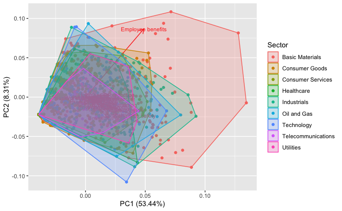

```r
autoplot(pca_res, data = pca_data, colour = 'Sector', loadings = T,
         loadings.label = TRUE, loadings.label.size = 3,
         frame = T)
```

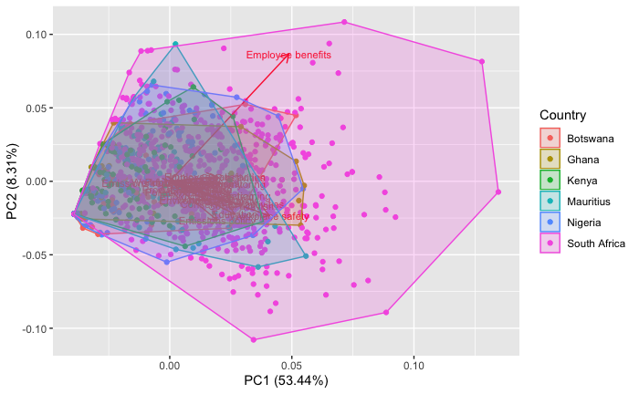

```r
autoplot(pca_res, data = pca_data, colour = 'Country', loadings = T,
         loadings.label = TRUE, loadings.label.size = 3,
         frame = T)
```

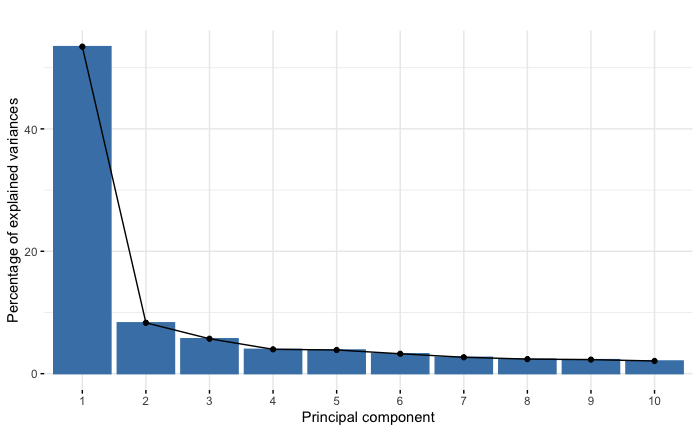

```r
fviz_eig(pca_res) + ggtitle("") + labs(x = 'Principal component')
```

### Predicted PCA scores

```r
# Results for individuals
res_ind <- get_pca_ind(pca_res)
pca_ind_scores <- res_ind$coord[, 1]        # Coordinates

usethis::use_data(pca_ind_scores, overwrite = TRUE)
```

```
✓ Saving 'pca_ind_scores' to 'data/pca_ind_scores.rda'
● Document your data (see 'https://r-pkgs.org/data.html')
```

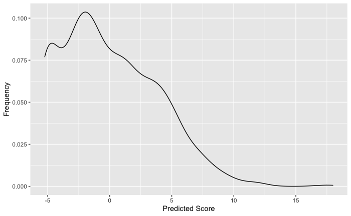

```r
ggplot() + aes(pca_ind_scores) +
  geom_density() +
  labs(x = "Predicted Score",
       y = "Frequency")
```

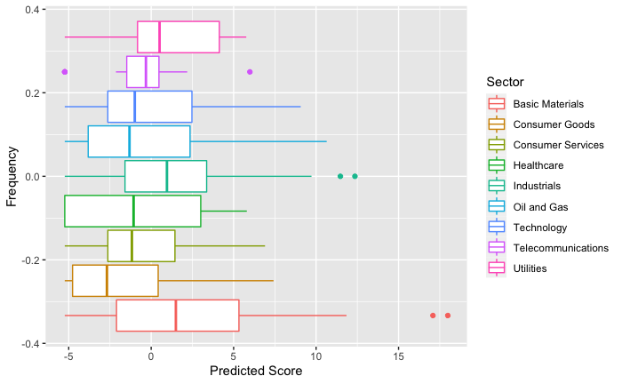

```r
pca_data$score <- pca_ind_scores
ggplot(pca_data, aes(score, colour = pca_data$Sector)) +
  geom_boxplot() +
  labs(x = "Predicted Score",
       y = "Frequency",
       colour = "Sector")
```

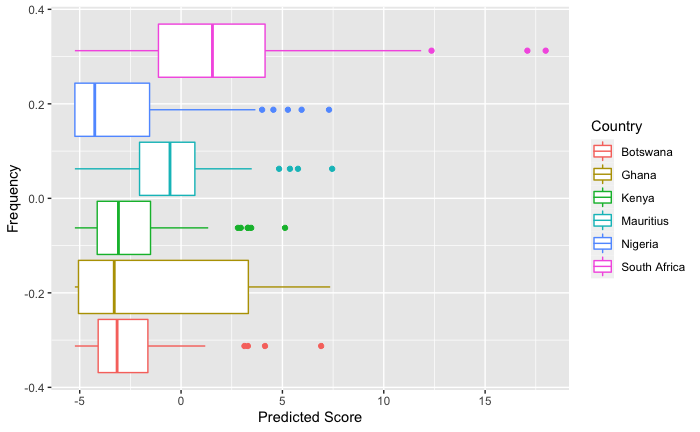

```r
ggplot(pca_data, aes(score, colour = pca_data$Country)) +
  geom_boxplot() +
  labs(x = "Predicted Score",
       y = "Frequency",
       colour = "Country")
```

## Analysis for Paper 2

General notes on analysis - Listing age (reporting year - listing year) may be < 0 as some companies reported whiles still private (these companies later got listed) - Consider excluding them or using incorporation age in analysis - including them may violate the condition that only listed companies are studied

- Multinational/local status implies that company may be required to report based on regulations from parent company’s country even if local country regulations do not
- Country of listing may be different from country of operation
- Sector:
  - Primary implies agriculture, extractive etc. Such companies face greater pressure to perform CSR

Covariates for Paper 2 - company age (incorporation age, listing age): include both - Sector: primary secondary tertiary - Firm size (ln(total assets))

Interaction variables - Presence of corporate social responsibility function

non linearity in relationship

### Subset data to use

- Net profit, total assets and book value of equity variables were coerced to strings in the data import even though they are supposed to be numeric. They are first converted to numeric by deleting all non-numeric characters

```r
library(ggfortify)
library(ggplot2)
```

| Country | Multinational | Sector | incorp_age | lag_return_on_assets | lag_return_on_equity | social_committee | reporting_year | pca_score |
| --- | --- | --- | --- | --- | --- | --- | --- | --- |
| Nigeria | Yes | Secondary | NA | NA | NA | 0 | 2014 | -5.036154116 |
| Nigeria | Yes | Secondary | NA | 3.187687e-02 | 6.479430e-02 | 0 | 2015 | -5.238641475 |
| Nigeria | Yes | Secondary | NA | 7.582210e-03 | 1.469964e-02 | 0 | 2016 | 0.627825887 |
| Nigeria | Yes | Secondary | NA | 7.310998e-02 | 2.850028e-01 | 0 | 2017 | -5.238641475 |
| Nigeria | Yes | Secondary | NA | 7.245481e-02 | 1.819193e-01 | 0 | 2018 | -4.292098653 |
| South Africa | No | Secondary | 162 | NA | NA | 0 | 2014 | -3.181740077 |
| South Africa | No | Secondary | 163 | 7.928446e-02 | 2.083049e-01 | 0 | 2015 | -1.841160983 |
| South Africa | No | Secondary | 164 | 7.328704e-02 | 2.158184e-01 | 0 | 2016 | -2.454674648 |
| South Africa | No | Secondary | 165 | 1.071673e-02 | 3.400675e-02 | 0 | 2017 | -0.027109589 |
| South Africa | No | Secondary | 166 | 3.731016e-02 | 1.144727e-01 | 0 | 2018 | 0.453229979 |

[output cut: 990 more lines]

```
$listing_country
    Botswana        Ghana        Kenya    Mauritius      Nigeria South Africa
          45           35          130           65          225          695

$locality
        Local Multinational
          425           770

$sector_class
  Primary Secondary  Tertiary
      340       510       345

$incorp_age
   Min. 1st Qu.  Median    Mean 3rd Qu.    Max.    NA's
   2.00   26.00   45.00   50.44   67.00  166.00      86

$lag_return_on_assets
     Min.   1st Qu.    Median      Mean   3rd Qu.      Max.      NA's
-31.36248   0.00007   0.02691   0.18613   0.07748  46.47262       268

$lag_return_on_equity
     Min.   1st Qu.    Median      Mean   3rd Qu.      Max.      NA's
-40.93999   0.00019   0.06561   0.17786   0.16266  33.67403       274

$social_committee
  0   1
558 637

$reporting_year
2014 2015 2016 2017 2018
 239  239  239  240  238

$pca_score
   Min. 1st Qu.  Median    Mean 3rd Qu.    Max.
 -5.239  -2.990  -0.605   0.000   2.719  17.987

$log_pca_score
   Min. 1st Qu.  Median    Mean 3rd Qu.    Max.
  0.000   1.178   1.729   1.581   2.192   3.187
```

```r
reg_data %>%
  set_variable_labels(
    listing_age = 'Listing age',
    incorp_age = 'Incorporation age',
    lag_return_on_assets = 'Return on assets',
    lag_return_on_equity = 'Return on equity',
    reporting_year = 'Report year',
    pca_score = 'PCA score',
    social_committee = 'Has social/ethics committee'
  ) %>%
  set_value_labels(
    social_committee = c(Yes = 1, No = 0)
  ) %>%
  tbl_summary(by = social_committee, missing = 'no') %>%
  add_p -> sumtable

sumtable %>%
  as_hux_table %>%
  insert_row('', 'Has Social and Ethics Committee', '', '', after = 0) %>%
  merge_cells(1, 2:3) %>%
  set_header_rows(1:2, TRUE) %>%
  style_headers(bold = TRUE, text_color = "grey40") %>%
  set_caption('Descriptive Statistics') %>%
  theme_article()
```

[output not shown]

```
 [1] "pca_score ~ lag_return_on_assets"
 [2] "pca_score ~ lag_return_on_equity"
 [3] "pca_score ~ lag_return_on_assets + reporting_year + Country + Sector + incorp_age + social_committee"
 [4] "pca_score ~ lag_return_on_equity + reporting_year + Country + Sector + incorp_age + social_committee"
 [5] "pca_score ~ lag_return_on_assets + I(lag_return_on_assets**2) + I(lag_return_on_assets**3)"
 [6] "pca_score ~ lag_return_on_equity + I(lag_return_on_equity**2) + I(lag_return_on_equity**3)"
 [7] "pca_score ~ lag_return_on_assets + I(lag_return_on_assets**2) + I(lag_return_on_assets**3) + reporting_year + Country + Sector + incorp_age + social_committee"
 [8] "pca_score ~ lag_return_on_equity + I(lag_return_on_equity**2) + I(lag_return_on_equity**3) + reporting_year + Country + Sector + incorp_age + social_committee"
 [9] "pca_score ~ (lag_return_on_assets + I(lag_return_on_assets**2) + I(lag_return_on_assets**3))*social_committee"
[10] "pca_score ~ (lag_return_on_equity + I(lag_return_on_equity**2) + I(lag_return_on_equity**3))*social_committee"
[11] "pca_score ~ (lag_return_on_assets + I(lag_return_on_assets**2) + I(lag_return_on_assets**3) + reporting_year + Country + Sector + incorp_age + social_committee)*social_committee"
[12] "pca_score ~ (lag_return_on_equity + I(lag_return_on_equity**2) + I(lag_return_on_equity**3) + reporting_year + Country + Sector + incorp_age + social_committee)*social_committee"
```

```r
model_fits <- lapply(models, lm, data = reg_data)
fits <- lapply(model_fits, function(x) coeftest(x, vcov = vcovHC(x, type="HC1")))
```

```r
lab <- c(
  "Return on assets" = "lag_return_on_assets",
  "Return on equity" = "lag_return_on_equity",
  "Reporting year : 2015" = "reporting_year2015",
  "Reporting year : 2016" = "reporting_year2016",
  "Reporting year : 2017" = "reporting_year2017",
  "Reporting year : 2018" = "reporting_year2018",
  "Country: Ghana" = "CountryGhana",
  "Country: Kenya" = "CountryKenya",
  "Country: Mauritius" = "CountryMauritius",
  "Country: Nigeria" = "CountryNigeria",
  "Country: South Africa" = "CountrySouth Africa",
  "Sector: Secondary" = "SectorSecondary",
  "Sector: Secondary" = "SectorTertiary",
  "Incorporation age" = "incorp_age",
  "Social committee" = "social_committee1"
)


huxreg(fits[1:4],
       error_pos = 'right', ci_level = .95, error_format = "({conf.low}, {conf.high})", number_format = 3,
       statistics = c('nobs', 'AIC'), coefs = lab) %>%
  set_contents(1, 2:9, c(rep('Unadjusted', 4), rep('Adjusted', 4))) %>%
  set_col_width(c(.2, rep(.1, 8))) %>%
  set_header_rows(1, TRUE) %>%
  style_headers(bold = TRUE, text_color = "grey40") %>%
  set_caption('Unadjusted and adjusted linear models') %>%
  merge_cells(row = 1, col = c(2, 3)) %>%
  merge_cells(row = 1, col = c(4, 5)) %>%
  merge_cells(row = 1, col = c(6, 7)) %>%
  merge_cells(row = 1, col = c(8, 9)) %>%
  theme_article()
```

```
                                                                               Unadjusted and adjusted linear models
                      ───────────────────────────────────────────────────────────────────────────────────────────────────────────────────────────────────────────────────────
                                                             Unadjusted                   Unadjusted                          Adjusted                          Adjusted
                      ───────────────────────────────────────────────────────────────────────────────────────────────────────────────────────────────────────────────────────
                        Return on assets           0.012   (-0.065, 0.089)                                   0.028        (-0.016, 0.072)
                        Return on equity                                        0.001   (-0.057, 0.059)                                       -0.001        (-0.055, 0.053)
                        Reporting year : 2015                                                               -5.782 ***   (-6.428, -5.136)     -5.730 ***   (-6.376, -5.084)
                        Reporting year : 2016                                                               -5.469 ***   (-6.148, -4.789)     -5.351 ***   (-6.027, -4.675)
                        Reporting year : 2017                                                               -5.382 ***   (-6.056, -4.709)     -5.311 ***   (-5.985, -4.637)
                        Reporting year : 2018                                                               -5.444 ***   (-6.151, -4.737)     -5.447 ***   (-6.159, -4.736)
                        Country: Ghana                                                                       1.655        (-0.093, 3.404)      1.645        (-0.094, 3.385)
                        Country: Kenya                                                                       0.059        (-1.003, 1.120)      0.006        (-1.069, 1.080)
                        Country: Mauritius                                                                   2.110 ***     (0.988, 3.233)      2.123 ***     (0.990, 3.256)
                        Country: Nigeria                                                                    -0.163        (-1.169, 0.843)     -0.179        (-1.191, 0.833)
                        Country: South Africa                                                                3.578 ***     (2.374, 4.783)      3.571 ***     (2.359, 4.782)
                        Sector: Secondary                                                                   -1.414 ***   (-1.969, -0.860)     -1.475 ***   (-2.026, -0.925)
                        Incorporation age                                                                    0.012 **      (0.004, 0.019)      0.011 **      (0.003, 0.019)
                        Social committee                                                                     1.182 **      (0.411, 1.954)      1.201 **      (0.428, 1.975)
                        nobs                     927                          921                          863                               856
                        AIC                     5142.517                     5112.777                     4406.042                          4363.412
                        *** p < 0.001; ** p < 0.01; * p < 0.05.
                      ───────────────────────────────────────────────────────────────────────────────────────────────────────────────────────────────────────────────────────

Column names: names, model1, model2, model3, model4, NA, NA, NA, NA
```

```r
dput(names(coef(fits[[3]])))
```

```
c("(Intercept)", "lag_return_on_assets", "reporting_year2015",
"reporting_year2016", "reporting_year2017", "reporting_year2018",
"CountryGhana", "CountryKenya", "CountryMauritius", "CountryNigeria",
"CountrySouth Africa", "SectorSecondary", "SectorTertiary", "incorp_age",
"social_committee1")
```

```r
lab <- c(
  "Return on assets" = "lag_return_on_assets",
  "ROA**2" = "I(lag_return_on_assets^2)",
  "ROA**3" = "I(lag_return_on_assets^3)",
  "Return on equity" = "lag_return_on_equity",
  "ROE**2" = "I(lag_return_on_equity^2)",
  "ROE**3" = "I(lag_return_on_equity^3)",
  "Reporting year : 2015" = "reporting_year2015",
  "Reporting year : 2016" = "reporting_year2016",
  "Reporting year : 2017" = "reporting_year2017",
  "Reporting year : 2018" = "reporting_year2018",
  "Country: Ghana" = "CountryGhana",
  "Country: Kenya" = "CountryKenya",
  "Country: Mauritius" = "CountryMauritius",
  "Country: Nigeria" = "CountryNigeria",
  "Country: South Africa" = "CountrySouth Africa",
  "Sector: Secondary" = "SectorSecondary",
  "Sector: Secondary" = "SectorTertiary",
  "Incorporation age" = "incorp_age",
  "Social committee" = "social_committee1"
)


huxreg(fits[5:8],
       error_pos = 'right', ci_level = .95, error_format = "({conf.low}, {conf.high})", number_format = 3,
       statistics = c('nobs', 'AIC'), coefs = lab) %>%
  set_contents(1, 2:9, c(rep('Unadjusted', 4), rep('Adjusted', 4))) %>%
  set_col_width(c(.2, rep(.1, 8))) %>%
  set_header_rows(1, TRUE) %>%
  style_headers(bold = TRUE, text_color = "grey40") %>%
  set_caption('Non-linear models') %>%
  merge_cells(row = 1, col = c(2, 3)) %>%
  merge_cells(row = 1, col = c(4, 5)) %>%
  merge_cells(row = 1, col = c(6, 7)) %>%
  merge_cells(row = 1, col = c(8, 9)) %>%
  theme_article()
```

```
                                                                                         Non-linear models
                      ───────────────────────────────────────────────────────────────────────────────────────────────────────────────────────────────────────────────────────
                                                             Unadjusted                   Unadjusted                          Adjusted                          Adjusted
                      ───────────────────────────────────────────────────────────────────────────────────────────────────────────────────────────────────────────────────────
                        Return on assets          -0.070   (-0.258, 0.119)                                   0.012        (-0.111, 0.134)
                        ROA**2                    -0.000   (-0.003, 0.003)                                  -0.000        (-0.002, 0.002)
                        ROA**3                     0.000   (-0.000, 0.000)                                   0.000        (-0.000, 0.000)
                        Return on equity                                        0.058   (-0.121, 0.236)                                        0.133        (-0.018, 0.284)
                        ROE**2                                                 -0.001   (-0.003, 0.002)                                       -0.001        (-0.004, 0.001)
                        ROE**3                                                 -0.000   (-0.000, 0.000)                                       -0.000        (-0.000, 0.000)
                        Reporting year : 2015                                                               -5.784 ***   (-6.431, -5.136)     -5.731 ***   (-6.376, -5.087)
                        Reporting year : 2016                                                               -5.470 ***   (-6.150, -4.790)     -5.364 ***   (-6.040, -4.688)
                        Reporting year : 2017                                                               -5.381 ***   (-6.055, -4.706)     -5.302 ***   (-5.977, -4.628)
                        Reporting year : 2018                                                               -5.447 ***   (-6.156, -4.737)     -5.465 ***   (-6.176, -4.754)
                        Country: Ghana                                                                       1.667        (-0.086, 3.420)      1.646        (-0.099, 3.392)
                        Country: Kenya                                                                       0.059        (-1.003, 1.122)      0.031        (-1.047, 1.109)
                        Country: Mauritius                                                                   2.117 ***     (0.992, 3.242)      2.050 ***     (0.910, 3.189)
                        Country: Nigeria                                                                    -0.163        (-1.170, 0.844)     -0.175        (-1.187, 0.838)
                        Country: South Africa                                                                3.579 ***     (2.371, 4.787)      3.558 ***     (2.342, 4.774)
                        Sector: Secondary                                                                   -1.411 ***   (-1.968, -0.854)     -1.475 ***   (-2.025, -0.925)
                        Incorporation age                                                                    0.012 **      (0.004, 0.019)      0.011 **      (0.003, 0.019)
                        Social committee                                                                     1.182 **      (0.409, 1.955)      1.232 **      (0.453, 2.011)
                        nobs                     927                          921                          863                               856
                        AIC                     5145.390                     5116.413                     4409.993                          4364.741
                        *** p < 0.001; ** p < 0.01; * p < 0.05.
                      ───────────────────────────────────────────────────────────────────────────────────────────────────────────────────────────────────────────────────────

Column names: names, model1, model2, model3, model4, NA, NA, NA, NA
```

```r
names(coef(fits[[7]]))
```

```
 [1] "(Intercept)"               "lag_return_on_assets"      "I(lag_return_on_assets^2)" "I(lag_return_on_assets^3)" "reporting_year2015"        "reporting_year2016"
 [7] "reporting_year2017"        "reporting_year2018"        "CountryGhana"              "CountryKenya"              "CountryMauritius"          "CountryNigeria"
[13] "CountrySouth Africa"       "SectorSecondary"           "SectorTertiary"            "incorp_age"                "social_committee1"
```

```r
lab <- c(
  "Return on assets" = "lag_return_on_assets",
  "ROA**2" = "I(lag_return_on_assets^2)",
  "ROA**3" = "I(lag_return_on_assets^3)",
  "Return on equity" = "lag_return_on_equity",
  "ROE**2" = "I(lag_return_on_equity^2)",
  "ROE**3" = "I(lag_return_on_equity^3)",
  "ROE x SC" = "lag_return_on_equity:social_committee1",
  "ROA x SC" = "lag_return_on_assets:social_committee1"
)

huxreg(fits[9:12],
       error_pos = 'right', ci_level = .95, error_format = "({conf.low}, {conf.high})", number_format = 3,
       statistics = c("N" = "nobs"), coefs = lab) %>%
  set_contents(1, 2:9, c(rep('Unadjusted', 4), rep('Adjusted', 4))) %>%
  set_col_width(c(.2, rep(.1, 8))) %>%
  set_header_rows(1, TRUE) %>%
  style_headers(bold = TRUE, text_color = "grey40") %>%
  set_caption('Non-linear models') %>%
  merge_cells(row = 1, col = c(2, 3)) %>%
  merge_cells(row = 1, col = c(4, 5)) %>%
  merge_cells(row = 1, col = c(6, 7)) %>%
  merge_cells(row = 1, col = c(8, 9)) %>%
  theme_article() %>%
  add_footnote('Models include interaction terms between SC and all other adjustment variables.
  Adjusted models are adjusted for country and year fixed-effects terms, industrial sector,
  incoporation year and presence of a social and ethics committee')
```

```
                                                                                         Non-linear models
                               ──────────────────────────────────────────────────────────────────────────────────────────────────────────────────────────────────────
                                                                  Unadjusted                  Unadjusted                    Adjusted                    Adjusted
                               ──────────────────────────────────────────────────────────────────────────────────────────────────────────────────────────────────────
                                 Return on assets    -0.065     (-0.247, 0.118)                                -0.048   (-0.220, 0.124)
                                 ROA**2               0.003     (-0.001, 0.007)                                -0.002   (-0.005, 0.002)
                                 ROA**3              -0.000     (-0.000, 0.000)                                 0.000   (-0.000, 0.000)
                                 Return on equity                                   0.065   (-0.075, 0.205)                                 0.060   (-0.126, 0.245)
                                 ROE**2                                            -0.001   (-0.003, 0.002)                                -0.001   (-0.003, 0.002)
                                 ROE**3                                            -0.000   (-0.000, 0.000)                                -0.000   (-0.000, 0.000)
                                 ROE x SC                                           0.243   (-0.082, 0.568)                                 0.204   (-0.103, 0.511)
                                 ROA x SC             0.226 *    (0.002, 0.449)                                 0.213   (-0.015, 0.442)
                                 N                  927                           921                         863                         856
                                 *** p < 0.001; ** p < 0.01; * p < 0.05.
                               ──────────────────────────────────────────────────────────────────────────────────────────────────────────────────────────────────────
                                 Models include interaction terms between SC and all other adjustment variables.
                                 Adjusted models are adjusted for country and year fixed-effects terms, industrial sector,
                                 incoporation year and presence of a social and ethics committee

Column names: names, model1, model2, model3, model4, NA, NA, NA, NA
```

```r
lr_tests
```

```
                                                           ──────────────────────────────────────────────────────────────────────────────
                                                             Models.to.compare                                                 p.values
                                                           ──────────────────────────────────────────────────────────────────────────────
                                                             Non-linear unadjusted vs. linear unadjusted (ROA)                 0.569
                                                             Non-linear unadjusted vs. linear unadjusted (ROE)                 0.834
                                                             Non-linear adjusted vs. linear adjusted (ROA)                     0.975
                                                             Non-linear adjusted vs. linear adjusted (ROE)                     0.263
                                                             Unadjusted interaction vs. non-linear unadjusted (ROA)            4.95e-51
                                                             Unadjusted interaction vs. non-linear unadjusted (ROE)            4.58e-50
                                                             Adjusted interaction vs. non-linear adjusted (ROA)                0.000678
                                                             Adjusted interaction vs. non-linear adjusted (ROE)                0.00146
                                                           ──────────────────────────────────────────────────────────────────────────────

Column names: Models.to.compare, p.values
```